# X Variables

Week 11

Alex Cardazzi

Old Dominion University

## Topics

- Distributed Lag Models
- Spurious Regression
- Cointegration

## GDP and the Yield Curve

[interactive chart not shown]

## GDP and the Yield Curve

```r
tmp <- read.csv("../data/fredgraph (2).csv")
colnames(tmp) <- c("DATE", "gdp_pc", "ir3m", "ir10y", "gdp")
rbind(head(tmp, 5), tail(tmp, 5))
```

```
          DATE  gdp_pc ir3m ir10y       gdp
1   1962-01-01 2.30808 2.72  3.86   594.013
2   1962-04-01 1.06951 2.73  4.00   600.366
3   1962-07-01 1.44262 2.78  3.94   609.027
4   1962-10-01 0.53413 2.87  3.85   612.280
5   1963-01-01 1.53394 2.89  3.95   621.672
208 2013-10-01 1.31302 0.07  3.04 17133.114
209 2014-01-01 0.06518 0.05  2.73 17144.281
210 2014-04-01 1.85731 0.04  2.53 17462.703
211 2014-07-01 1.60642 0.02  2.52 17743.227
212 2014-10-01 0.61608 0.03  2.17 17852.540
```

## GDP and the Yield Curve

Once you have your data, you might need to add/modify variables.

- Do this *before* converting to a `ts()` object.

```r
tmp$spread <- tmp$ir10y - tmp$ir3m
```

## GDP and the Yield Curve

You can also do this after:

```r
tmp <- ts(tmp, start = c(1962, 1), frequency = 4)
# ts.union vs ts.intersect
tmp <- ts.union(tmp, spread = tmp[,"ir10y"] - tmp[,"ir3m"], dframe = FALSE)
rbind(head(tmp, 3), tail(tmp, 3))

colnames(tmp) <- gsub("tmp.", "", colnames(tmp))
```

```
     tmp.DATE tmp.gdp_pc tmp.ir3m tmp.ir10y   tmp.gdp tmp.spread spread
[1,]        1    2.30808     2.72      3.86   594.013       1.14   1.14
[2,]        2    1.06951     2.73      4.00   600.366       1.27   1.27
[3,]        3    1.44262     2.78      3.94   609.027       1.16   1.16
[4,]      210    1.85731     0.04      2.53 17462.703       2.49   2.49
[5,]      211    1.60642     0.02      2.52 17743.227       2.50   2.50
[6,]      212    0.61608     0.03      2.17 17852.540       2.14   2.14
```

## Distributed Lags

What if you need to manipulate the data?

```r
head(ts.union(y = tmp[,"gdp_pc"],
              diff_y = diff(tmp[,"gdp"]),
              pc_y = 100*diff(tmp[,"gdp"])/tmp[,"gdp"]), 10)
```

```
              y diff_y      pc_y
1962 Q1 2.30808     NA        NA
1962 Q2 1.06951  6.353 1.0581878
1962 Q3 1.44262  8.661 1.4221044
1962 Q4 0.53413  3.253 0.5312929
1963 Q1 1.53394  9.392 1.5107645
1963 Q2 1.29972  8.080 1.2830448
1963 Q3 2.33298 14.692 2.2797947
1963 Q4 1.47321  9.494 1.4518196
1964 Q1 2.42898 15.884 2.3713763
1964 Q2 1.32155  8.852 1.3043081
```

## GDP and the Yield Curve

```r
plot(tmp[,c("gdp_pc")], ylim = range(tmp[,c("gdp_pc", "spread")]),
     col = alpha("tomato", .6), lwd = 2)
lines(tmp[,"spread"], col = alpha("dodgerblue", .6), lwd = 2)
abline(h = 0)
legend("topright", lty = 1, col = c("tomato", "dodgerblue"),
       legend = c("%C GDP", "Spread"), bty = "n")
```

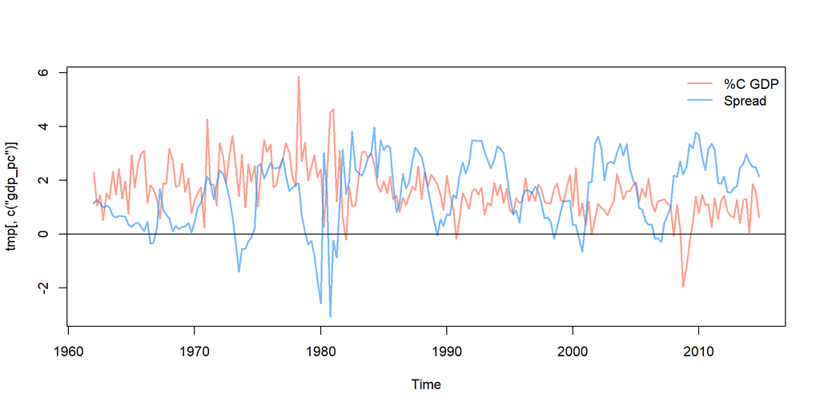

## GDP and the Yield Curve

Check for stationarity:

```r
adf.test(tmp[,"gdp_pc"])
adf.test(tmp[,"spread"])
```

```
    Augmented Dickey-Fuller Test

data:  tmp[, "gdp_pc"]
Dickey-Fuller = -5.0107, Lag order = 5, p-value = 0.01
alternative hypothesis: stationary


    Augmented Dickey-Fuller Test

data:  tmp[, "spread"]
Dickey-Fuller = -4.9057, Lag order = 5, p-value = 0.01
alternative hypothesis: stationary
```

- ACF
- PACF

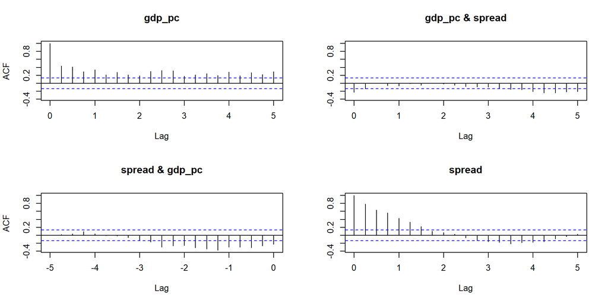

```r
acf(tmp[,c("gdp_pc", "spread")])
```

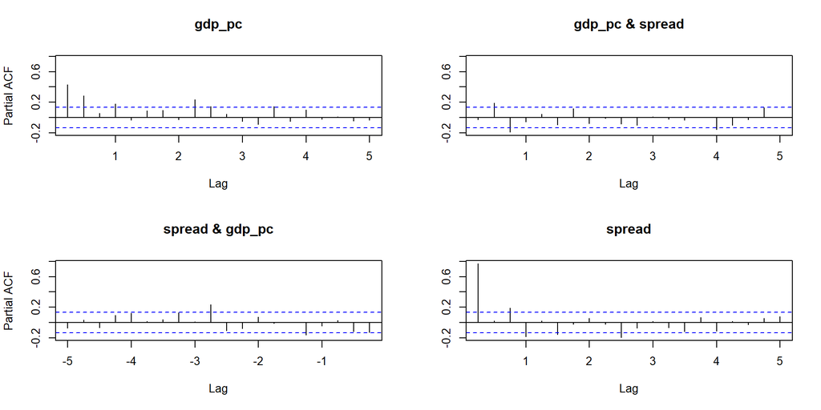

```r
pacf(tmp[,c("gdp_pc", "spread")])
```

## Distributed Lags

There are two (main) options to estimating DL models:

`dynlm`, `dynlm()`

- Data can be a `ts()` object.
- Lags are (IMO) more intuitive.
- No method for prediction

`dLagM`, `ardlDlm()`

- Data must be a `data.frame` object.
- Lags are less intuitive.
- Cannot be (easily) used with `stargazer`

```r
library("dynlm")
library("dLagM")
```

# `dynlm`

## Distributed Lags

Main model: `dynlm()`

- To use lags, use `L()`
  - `L(var, i:j)`
  - `i:j` is a vector for the lag structure. This can be any vector.

## Distributed Lags

```r
r1 <- dynlm(tmp[,"gdp_pc"] ~ tmp[,"spread"])
r2 <- lm(tmp[,"gdp_pc"] ~ tmp[,"spread"])
stargazer::stargazer(r1, r2, type = "html")
```

|  | *Dependent variable:* |  |
| --- | --- | --- |
|  | tmp[, “gdp_pc”] |  |
|  | *dynamic* | *OLS* |
|  | *linear* |  |
|  | (1) | (2) |
| tmp[, “spread”] | -0.166*** | -0.166*** |
|  | (0.051) | (0.051) |
| Constant | 1.888*** | 1.888*** |
|  | (0.101) | (0.101) |
| Observations | 212 | 212 |
| R<sup>2</sup> | 0.048 | 0.048 |
| Adjusted R<sup>2</sup> | 0.044 | 0.044 |
| Residual Std. Error (df = 210) | 0.938 | 0.938 |
| F Statistic (df = 1; 210) | 10.659*** | 10.659*** |
| *Note:* | *p<0.1; **p<0.05;*** p<0.01 |  |

## Distributed Lags

```r
r1 <- dynlm(tmp[,"gdp_pc"] ~ tmp[,"spread"] + L(tmp[,"spread"]))
r2 <- dynlm(tmp[,"gdp_pc"] ~ L(tmp[,"spread"], 0:1))
r3 <- dynlm(gdp_pc ~ L(spread, 0:1), tmp)
stargazer::stargazer(r1, r2, r3, type = "html")
```

|  | *Dependent variable:* |  |  |
| --- | --- | --- | --- |
|  | tmp[, “gdp_pc”] |  | gdp_pc |
|  | (1) | (2) | (3) |
| tmp[, “spread”] | -0.229*** |  |  |
|  | (0.083) |  |  |
| L(tmp[, “spread”]) | 0.081 |  |  |
|  | (0.083) |  |  |
| L(tmp[, “spread”], 0:1)0 |  | -0.229*** |  |
|  |  | (0.083) |  |
| L(tmp[, “spread”], 0:1)1 |  | 0.081 |  |
|  |  | (0.083) |  |
| L(spread, 0:1)0 |  |  | -0.229*** |
|  |  |  | (0.083) |
| L(spread, 0:1)1 |  |  | 0.081 |
|  |  |  | (0.083) |
| Constant | 1.858*** | 1.858*** | 1.858*** |
|  | (0.105) | (0.105) | (0.105) |
| Observations | 211 | 211 | 211 |
| R<sup>2</sup> | 0.052 | 0.052 | 0.052 |
| Adjusted R<sup>2</sup> | 0.043 | 0.043 | 0.043 |
| Residual Std. Error (df = 208) | 0.939 | 0.939 | 0.939 |
| F Statistic (df = 2; 208) | 5.743*** | 5.743*** | 5.743*** |
| *Note:* | *p<0.1; **p<0.05;*** p<0.01 |  |  |

## Distributed Lags

```r
r1 <- dynlm(gdp_pc ~ L(spread, 0), tmp)
r2 <- dynlm(gdp_pc ~ L(spread, 0:4), tmp)
r3 <- dynlm(gdp_pc ~ L(spread, 0:8), tmp)
stargazer::stargazer(r1, r2, r3,
                     add.lines = list(c("AIC",
                                        round(AIC(r1), 2),
                                        round(AIC(r2), 2),
                                        round(AIC(r3), 2))),
                     omit.stat = c("ser", "f"),
                     type = "html")
```

|  | *Dependent variable:* |  |  |
| --- | --- | --- | --- |
|  | gdp_pc |  |  |
|  | (1) | (2) | (3) |
| L(spread, 0) | -0.166*** |  |  |
|  | (0.051) |  |  |
| L(spread, 0:4)0 |  | -0.236*** |  |
|  |  | (0.085) |  |
| L(spread, 0:4)1 |  | -0.076 |  |
|  |  | (0.107) |  |
| L(spread, 0:4)2 |  | 0.256** |  |
|  |  | (0.105) |  |
| L(spread, 0:4)3 |  | -0.021 |  |
|  |  | (0.107) |  |
| L(spread, 0:4)4 |  | -0.051 |  |
|  |  | (0.085) |  |
| L(spread, 0:8)0 |  |  | -0.249*** |
|  |  |  | (0.088) |
| L(spread, 0:8)1 |  |  | -0.051 |
|  |  |  | (0.113) |
| L(spread, 0:8)2 |  |  | 0.208* |
|  |  |  | (0.113) |
| L(spread, 0:8)3 |  |  | 0.035 |
|  |  |  | (0.116) |
| L(spread, 0:8)4 |  |  | -0.122 |
|  |  |  | (0.117) |
| L(spread, 0:8)5 |  |  | 0.139 |
|  |  |  | (0.117) |
| L(spread, 0:8)6 |  |  | -0.129 |
|  |  |  | (0.113) |
| L(spread, 0:8)7 |  |  | 0.075 |
|  |  |  | (0.113) |
| L(spread, 0:8)8 |  |  | -0.052 |
|  |  |  | (0.088) |
| Constant | 1.888*** | 1.837*** | 1.867*** |
|  | (0.101) | (0.113) | (0.129) |
| AIC | 578.35 | 568.22 | 566.86 |
| Observations | 212 | 208 | 204 |
| R<sup>2</sup> | 0.048 | 0.089 | 0.098 |
| Adjusted R<sup>2</sup> | 0.044 | 0.067 | 0.056 |
| *Note:* | *p<0.1; **p<0.05;*** p<0.01 |  |  |

## Distributed Lags

```r
r1 <- dynlm(gdp_pc ~ L(spread, 0),
            ts(tmp[9:212,], end = c(2014, 4), frequency = 4))
r2 <- dynlm(gdp_pc ~ L(spread, 0:4),
            ts(tmp[5:212,], end = c(2014, 4), frequency = 4))
r3 <- dynlm(gdp_pc ~ L(spread, 0:8), tmp)
stargazer::stargazer(r1, r2, r3,
                     add.lines = list(c("AIC",
                                        round(AIC(r1), 2),
                                        round(AIC(r2), 2),
                                        round(AIC(r3), 2))),
                     omit.stat = c("ser", "f"),
                     type = "html")
```

|  | *Dependent variable:* |  |  |
| --- | --- | --- | --- |
|  | gdp_pc |  |  |
|  | (1) | (2) | (3) |
| L(spread, 0) | -0.168*** |  |  |
|  | (0.052) |  |  |
| L(spread, 0:4)0 |  | -0.236*** |  |
|  |  | (0.086) |  |
| L(spread, 0:4)1 |  | -0.078 |  |
|  |  | (0.108) |  |
| L(spread, 0:4)2 |  | 0.256** |  |
|  |  | (0.106) |  |
| L(spread, 0:4)3 |  | -0.020 |  |
|  |  | (0.108) |  |
| L(spread, 0:4)4 |  | -0.051 |  |
|  |  | (0.086) |  |
| L(spread, 0:8)0 |  |  | -0.249*** |
|  |  |  | (0.088) |
| L(spread, 0:8)1 |  |  | -0.051 |
|  |  |  | (0.113) |
| L(spread, 0:8)2 |  |  | 0.208* |
|  |  |  | (0.113) |
| L(spread, 0:8)3 |  |  | 0.035 |
|  |  |  | (0.116) |
| L(spread, 0:8)4 |  |  | -0.122 |
|  |  |  | (0.117) |
| L(spread, 0:8)5 |  |  | 0.139 |
|  |  |  | (0.117) |
| L(spread, 0:8)6 |  |  | -0.129 |
|  |  |  | (0.113) |
| L(spread, 0:8)7 |  |  | 0.075 |
|  |  |  | (0.113) |
| L(spread, 0:8)8 |  |  | -0.052 |
|  |  |  | (0.088) |
| Constant | 1.901*** | 1.840*** | 1.867*** |
|  | (0.104) | (0.115) | (0.129) |
| AIC | 561.41 | 560.82 | 566.86 |
| Observations | 204 | 204 | 204 |
| R<sup>2</sup> | 0.050 | 0.089 | 0.098 |
| Adjusted R<sup>2</sup> | 0.045 | 0.066 | 0.056 |
| *Note:* | *p<0.1; **p<0.05;*** p<0.01 |  |  |

## Distributed Lags

```r
r1 <- dynlm(gdp_pc ~ L(gdp_pc, 1:2), tmp)
r2 <- dynlm(gdp_pc ~ L(spread, 0:2), tmp)
r3 <- dynlm(gdp_pc ~ L(gdp_pc, 1:2) + L(spread, 0:2), tmp)
stargazer::stargazer(r1, r2, r3,
                     add.lines = list(c("AIC",
                                        round(AIC(r1), 2),
                                        round(AIC(r2), 2),
                                        round(AIC(r3), 2))),
                     omit.stat = c("ser", "f"),
                     type = "html")
```

|  | *Dependent variable:* |  |  |
| --- | --- | --- | --- |
|  | gdp_pc |  |  |
|  | (1) | (2) | (3) |
| L(gdp_pc, 1:2)1 | 0.323*** |  | 0.300*** |
|  | (0.067) |  | (0.067) |
| L(gdp_pc, 1:2)2 | 0.275*** |  | 0.272*** |
|  | (0.067) |  | (0.068) |
| L(spread, 0:2)0 |  | -0.233*** | -0.121 |
|  |  | (0.082) | (0.074) |
| L(spread, 0:2)1 |  | -0.086 | -0.054 |
|  |  | (0.104) | (0.092) |
| L(spread, 0:2)2 |  | 0.215*** | 0.192*** |
|  |  | (0.082) | (0.073) |
| Constant | 0.654*** | 1.796*** | 0.673*** |
|  | (0.129) | (0.107) | (0.174) |
| AIC | 523.84 | 570.27 | 520.33 |
| Observations | 210 | 210 | 210 |
| R<sup>2</sup> | 0.258 | 0.083 | 0.291 |
| Adjusted R<sup>2</sup> | 0.251 | 0.070 | 0.273 |
| *Note:* | *p<0.1; **p<0.05;*** p<0.01 |  |  |

# `dLagM`

## Distributed Lags

Main model: `ardlDlm()`

- To use lags, use `p` and `q`.
  - `p` denotes lags of $X$
  - `q` denotes lags of $Y$
  - use `remove` to omit lags you are uninterested in.

## Distributed Lags

- DL(2)
- AR(2)
- ARDL(2,2)
- ARDL(2,2)$^*$

```r
rmv.q <- c(1) # y-vars
rmv.p <- list(spread = c()) # x-vars
rmv <- list(p = rmv.p, q = rmv.q)
r1 <- ardlDlm(formula = gdp_pc ~ spread,
              data = as.data.frame(tmp),
              p = 2,
              q = 1,
              remove = rmv)
summary(r1)
```

```
Time series regression with "ts" data:
Start = 3, End = 212

Call:
dynlm(formula = as.formula(model.text), data = data)

Residuals:
    Min      1Q  Median      3Q     Max
-3.4535 -0.5826 -0.0839  0.4303  4.2882

Coefficients:
            Estimate Std. Error t value Pr(>|t|)
(Intercept)  1.79552    0.10671  16.827  < 2e-16 ***
spread.t    -0.23343    0.08199  -2.847  0.00486 **
spread.1    -0.08588    0.10367  -0.828  0.40844
spread.2     0.21504    0.08209   2.620  0.00946 **
---
Signif. codes:  0 '***' 0.001 '**' 0.01 '*' 0.05 '.' 0.1 ' ' 1

Residual standard error: 0.9274 on 206 degrees of freedom
Multiple R-squared:  0.08314,   Adjusted R-squared:  0.06978
F-statistic: 6.226 on 3 and 206 DF,  p-value: 0.0004562
```

```r
rmv.q <- c() # y-vars
rmv.p <- list(spread = c(1)) # x-vars
rmv <- list(p = rmv.p, q = rmv.q)
r2 <- ardlDlm(formula = gdp_pc ~ spread,
              data = as.data.frame(tmp),
              p = 1,
              q = 2,
              remove = rmv)
summary(r2)
```

```
Time series regression with "ts" data:
Start = 3, End = 212

Call:
dynlm(formula = as.formula(model.text), data = data)

Residuals:
    Min      1Q  Median      3Q     Max
-2.9672 -0.4680 -0.0485  0.3921  4.0502

Coefficients:
            Estimate Std. Error t value Pr(>|t|)
(Intercept)  0.75420    0.17331   4.352 2.12e-05 ***
spread.t    -0.04155    0.04794  -0.867 0.387132
gdp_pc.1     0.31456    0.06766   4.649 5.96e-06 ***
gdp_pc.2     0.26149    0.06862   3.810 0.000183 ***
---
Signif. codes:  0 '***' 0.001 '**' 0.01 '*' 0.05 '.' 0.1 ' ' 1

Residual standard error: 0.8328 on 206 degrees of freedom
Multiple R-squared:  0.2607,    Adjusted R-squared:  0.2499
F-statistic: 24.21 on 3 and 206 DF,  p-value: 1.835e-13
```

```r
rmv.q <- c() # y-vars
rmv.p <- list(spread = c()) # x-vars
rmv <- list(p = rmv.p, q = rmv.q)
r3 <- ardlDlm(formula = gdp_pc ~ spread,
              data = as.data.frame(tmp),
              p = 2,
              q = 2,
              remove = rmv)
summary(r3)
```

```
Time series regression with "ts" data:
Start = 3, End = 212

Call:
dynlm(formula = as.formula(model.text), data = data)

Residuals:
    Min      1Q  Median      3Q     Max
-2.9803 -0.5649 -0.0341  0.4066  4.0575

Coefficients:
            Estimate Std. Error t value Pr(>|t|)
(Intercept)  0.67306    0.17356   3.878 0.000142 ***
spread.t    -0.12124    0.07392  -1.640 0.102518
spread.1    -0.05366    0.09178  -0.585 0.559402
spread.2     0.19217    0.07283   2.639 0.008967 **
gdp_pc.1     0.29954    0.06685   4.481 1.24e-05 ***
gdp_pc.2     0.27183    0.06763   4.019 8.21e-05 ***
---
Signif. codes:  0 '***' 0.001 '**' 0.01 '*' 0.05 '.' 0.1 ' ' 1

Residual standard error: 0.8196 on 204 degrees of freedom
Multiple R-squared:  0.2908,    Adjusted R-squared:  0.2735
F-statistic: 16.73 on 5 and 204 DF,  p-value: 7.663e-14
```

```r
rmv.q <- c(1) # y-vars
rmv.p <- list(spread = c(0,1)) # x-vars
rmv <- list(p = rmv.p, q = rmv.q)
r4 <- ardlDlm(formula = gdp_pc ~ spread,
              data = as.data.frame(tmp),
              p = 2,
              q = 2,
              remove = rmv)
summary(r4)
```

```
Time series regression with "ts" data:
Start = 3, End = 212

Call:
dynlm(formula = as.formula(model.text), data = data)

Residuals:
    Min      1Q  Median      3Q     Max
-3.3836 -0.5389 -0.0403  0.4194  3.9753

Coefficients:
            Estimate Std. Error t value Pr(>|t|)
(Intercept)  0.80640    0.15393   5.239 3.97e-07 ***
spread.2     0.07091    0.04848   1.463    0.145
gdp_pc.2     0.43832    0.06443   6.803 1.08e-10 ***
---
Signif. codes:  0 '***' 0.001 '**' 0.01 '*' 0.05 '.' 0.1 ' ' 1

Residual standard error: 0.8735 on 207 degrees of freedom
Multiple R-squared:  0.1827,    Adjusted R-squared:  0.1748
F-statistic: 23.14 on 2 and 207 DF,  p-value: 8.521e-10
```

## A Note: Granger Causality

Granger Causality is when lags of $X$ predict future values of $Y$.

Granger Causality $\neq$ (Mixtape) Causality!

- Term spread does not *cause* GDP to decrease.
- Term spread *today* is correlated with future changes in GDP.
  - It is more likely that investor sentiment about future GDP causes term spread to change.
  - GDP causes Spread
  - Spread “Granger causes” GDP

## A Note: Granger Causality

```r
lmtest::grangertest(gdp_pc ~ spread, tmp, order = 1)
lmtest::grangertest(gdp_pc ~ spread, tmp, order = 2)
```

```
Granger causality test

Model 1: gdp_pc ~ Lags(gdp_pc, 1:1) + Lags(spread, 1:1)
Model 2: gdp_pc ~ Lags(gdp_pc, 1:1)
  Res.Df Df      F Pr(>F)
1    208
2    209 -1 0.3653 0.5462
Granger causality test

Model 1: gdp_pc ~ Lags(gdp_pc, 1:2) + Lags(spread, 1:2)
Model 2: gdp_pc ~ Lags(gdp_pc, 1:2)
  Res.Df Df      F  Pr(>F)
1    205
2    207 -2 3.3511 0.03698 *
---
Signif. codes:  0 '***' 0.001 '**' 0.01 '*' 0.05 '.' 0.1 ' ' 1
```

## Forecasting with X

```r
forecast(model,
         x,
         h = 1,
         interval = FALSE,
         level = 0.95)
```

- `model`: a fitted `ardlDlm` object
- `x`: values for $X_{t+1}, ..., X_{t+h}$
- `h`: similar to `n.ahead`

## Forecasting with X

We are interested in forecasting GDP. Let’s write some of the equations we believe:

$$\begin{align}\%\Delta \text{GDP}_t &= \alpha + \sum_{i = 1}^{2}\beta_i \%\Delta \text{GDP}_{t-i} + \gamma\text{S}_{t-2} + e_t \\
S_t &\sim ARIMA(p,d, q)\end{align}$$

We can fit both of these using `auto.arima` and `ardlDlm`. We will forecast 2013 and 2014.

## Forecasting with X

Step 1: Generate a model for $\%\Delta \text{GDP}_t$.

- Use `ardlDlm()` to fit estimate parameters.
- The structure of the model is determined from previous results.

```r
c_namez <- colnames(tmp)
tmp <- ts.union(tmp, h = ifelse(time(tmp) >= 2013, 1, 0))
colnames(tmp) <- c(c_namez, "h")
lim <- tmp[,"h"] == 0

rmv.q <- c() # y-vars
rmv.p <- list(spread = c(0,1)) # x-vars
rmv <- list(p = rmv.p, q = rmv.q)
main <- ardlDlm(formula = gdp_pc ~ spread,
              data = as.data.frame(tmp[lim,]),
              p = 2,
              q = 2,
              remove = rmv)
summary(main)
```

```
Time series regression with "ts" data:
Start = 3, End = 204

Call:
dynlm(formula = as.formula(model.text), data = data)

Residuals:
    Min      1Q  Median      3Q     Max
-3.0118 -0.5101 -0.0496  0.3926  3.9909

Coefficients:
            Estimate Std. Error t value Pr(>|t|)
(Intercept)  0.48808    0.16204   3.012  0.00293 **
spread.2     0.08388    0.04648   1.805  0.07264 .
gdp_pc.1     0.33251    0.06776   4.907 1.92e-06 ***
gdp_pc.2     0.29455    0.06887   4.277 2.95e-05 ***
---
Signif. codes:  0 '***' 0.001 '**' 0.01 '*' 0.05 '.' 0.1 ' ' 1

Residual standard error: 0.8306 on 198 degrees of freedom
Multiple R-squared:  0.2725,    Adjusted R-squared:  0.2615
F-statistic: 24.72 on 3 and 198 DF,  p-value: 1.254e-13
```

## Forecasting with X

Step 2: Generate a model for $S_t$.

- Use `auto.arima()` for simplicity.
- Forecasts from this model will be used in future steps.

```r
sub <- auto.arima(tmp[lim,"spread"])
summary(sub)
```

```
Series: tmp[lim, "spread"]
ARIMA(1,1,2)

Coefficients:
          ar1     ma1      ma2
      -0.5572  0.4556  -0.3120
s.e.   0.1610  0.1575   0.0695

sigma^2 = 0.6389:  log likelihood = -241.21
AIC=490.42   AICc=490.63   BIC=503.68

Training set error measures:
                      ME      RMSE       MAE      MPE     MAPE     MASE
Training set 0.003708918 0.7914635 0.5326302 4.411761 69.15104 1.014201
                    ACF1
Training set -0.00432909
```

## Forecasting with X

```r
p <- predict(sub, n.ahead = 8)
plot(tmp[,"spread"], lwd = 1,
     ylim = c(-1, 4),
     xlim = c(2000, 2015),
     xlab = "Quarter", ylab = "Percentage Points",
     main = "Term Spread (10Y - 3M)")
lines(seq(2013, 2014.75, by = 1/4),
      tmp[!lim,"spread"], col = "dodgerblue", lwd = 3)
lines(seq(2013, 2014.75, by = 1/4),
      p$pred, col = "tomato", lwd = 3)
legend("bottomright", bty = "n", lty = 1,
       col = c("tomato", "dodgerblue"),
       legend = c("Forecast", "Actual"))
```

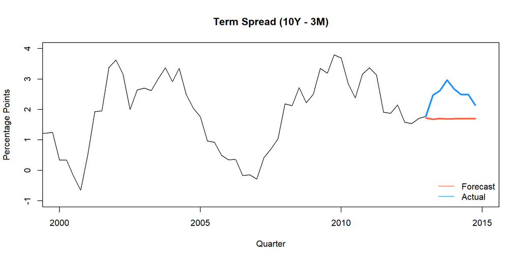

## Forecasting with X

```r
r1 <- auto.arima(tmp[lim,"gdp_pc"])
p1 <- predict(r1, n.ahead = 8)

forecast(model = main,
         x = p$pred,
         h = 8,
         interval = FALSE) -> f
plot(tmp[,"gdp_pc"],
     ylim = c(-2, 3),
     xlim = c(2000, 2015),
     xlab = "Quarter", ylab = "Percentage Points",
     main = "Percent Change in GDP")
lines(seq(2013, 2014.75, by = 1/4),
      tmp[!lim,"gdp_pc"], col = "dodgerblue", lwd = 3)
lines(seq(2013, 2014.75, by = 1/4),
      f$forecasts, col = "tomato", lwd = 3)
lines(seq(2013, 2014.75, by = 1/4), lwd = 3,
      as.numeric(p1$pred), col = "mediumseagreen")
legend("bottomright", bty = "n", lty = 1,
       col = c("tomato", "mediumseagreen", "dodgerblue"),
       legend = c("ARDL Forecast", "ARIMA Forecast" , "Actual"))
```

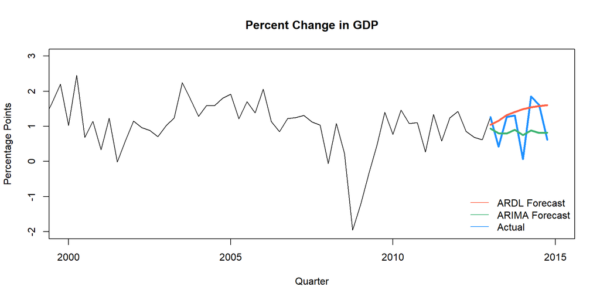

## Forecasting with X

```r
c_namez <- colnames(tmp)
tmp <- ts.intersect(tmp, spread_l2 = lag(tmp[,"spread"], -2))
colnames(tmp) <- c(c_namez, "spread_l2")

r1 <- auto.arima(tmp[,"gdp_pc"])
r2 <- auto.arima(tmp[,"gdp_pc"], xreg = tmp[,"spread_l2"])
```

## Forecasting with X

```r
r1
```

```
Series: tmp[, "gdp_pc"]
ARIMA(0,1,3)(2,0,1)[4]

Coefficients:
          ma1     ma2      ma3    sar1     sar2     sma1
      -0.7283  0.0028  -0.1612  0.3949  -0.1987  -0.3020
s.e.   0.0688  0.0891   0.0660  0.2215   0.0707   0.2222

sigma^2 = 0.6461:  log likelihood = -248.75
AIC=511.5   AICc=512.06   BIC=534.9
```

```r
r2
```

```
Series: tmp[, "gdp_pc"]
Regression with ARIMA(0,1,2)(2,0,2)[4] errors

Coefficients:
          ma1      ma2    sar1     sar2     sma1    sma2    drift    xreg
      -0.7207  -0.1499  0.3426  -0.5230  -0.2175  0.3599  -0.0054  0.1829
s.e.   0.0639   0.0711  0.3713   0.2233   0.4182  0.2599   0.0071  0.0589

sigma^2 = 0.6321:  log likelihood = -245.38
AIC=508.76   AICc=509.67   BIC=538.84
```

# Cointegration

## Cointegration

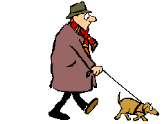

eco.uc3m.es/~jgonzalo/teaching/econometriaii/cointegration.htm

## Cointegration

Suppose we want to model consumption as a function of income. If we assume consumption is some *constant* fraction of your income (according to economic theory), we could write the following model:

$$C_t = kI_t$$

We can rewrite this as:

$$\begin{align}log(C_t) &= log(kY_t) \\ &= log(k) + log(Y_t)\end{align}$$

## Cointegration

We can also say that:

$$\begin{align} \Delta log(C_t) &= log(C_t) - log(C_{t-1})\\ &= log(k) + log(Y_t) - (log(k) + log(Y_{t-1})) \\
&= log(k)-log(k) + log(Y_t) - log(Y_{t-1}) \\
&= \Delta log(Y_{t})\end{align}$$

## Cointegration

Let’s suppose we estimated the following model (in logs):

$$C_t = \beta_0 + \beta_1 Y_t + \beta_2 Y_{t-1} + \alpha C_{t-1}$$

In the long run, we should find an equilibrium $C^*$ and $Y^*$:

$$C^* = \beta_0 + \beta_1 Y^* + \beta_2 Y^* + \alpha C^*$$

Simplifying:

$$(1-\alpha)C^* = \beta_0 + (\beta_1 + \beta_2) Y^*$$

## Cointegration

$$(1-\alpha)C^* = \beta_0 + (\beta_1 + \beta_2) Y^*$$

Since $\Delta log(C_t) = \Delta log(Y_t)$, then $1-\alpha = \beta_1 + \beta_2$.

Let $\gamma = 1-\alpha = \beta_1 + \beta_2$.

$$\begin{align}\alpha &= 1 - \gamma \\ \beta_2 &= \gamma - \beta_1\end{align}$$

## Cointegration

$$C_t = \beta_0 + \beta_1 Y_t + \color{red}{\beta_2} Y_{t-1} + \color{red}{\alpha} C_{t-1}$$

$$C_t = \beta_0 + \beta_1 Y_t + (\gamma - \beta_1) Y_{t-1} + (1-\gamma) C_{t-1}$$

$$C_t - C_{t-1} = \beta_0 + \beta_1 Y_t - \beta_1 Y_{t-1} + \gamma Y_{t-1} - \gamma C_{t-1}$$

$$C_t - C_{t-1} = \beta_0 + \beta_1 (Y_t - Y_{t-1}) + \gamma (Y_{t-1} - C_{t-1})$$

$$\Delta C_t = f(\Delta Y_t, Y_{t-1} - C_{t-1})$$

Where:

- $\Delta Y_t$ is the short run relationship
- $Y_{t-1} - C_{t-1}$ is the long run equilibrium

## Cointegration

Idea: Two or more non-stationary processes may be linked through an equilibrium.

Consumption & Income

- Overspending: liquidity constraint
- Underspending: not optimizing
- **Utility Maximization**

## Cointegration

```r
pi <- read.csv("../data/inc_pce.csv")
pi$DATE <- ymd(pi$DATE)
par(mfrow = c(1, 2))
plot(pi$DATE, pi$PI, type = "l",
     ylim = range(pi$PI, pi$PCE),
     xlab = "Date", ylab = "log($)",
     col = "tomato")
lines(pi$DATE, pi$PCE, type = "l", col = "dodgerblue")
legend("topleft", legend = c("PI", "PCE"),
       col = c("tomato", "dodgerblue"),
       lty = 1, bty = "n")

plot(pi$DATE, log(pi$PI), type = "l",
     ylim = log(range(pi$PI, pi$PCE)),
     xlab = "Date", ylab = "log($)",
     col = "tomato")
lines(pi$DATE, log(pi$PCE), type = "l", col = "dodgerblue")
legend("topleft", legend = c("PI", "PCE"),
       col = c("tomato", "dodgerblue"),
       lty = 1, bty = "n")
```

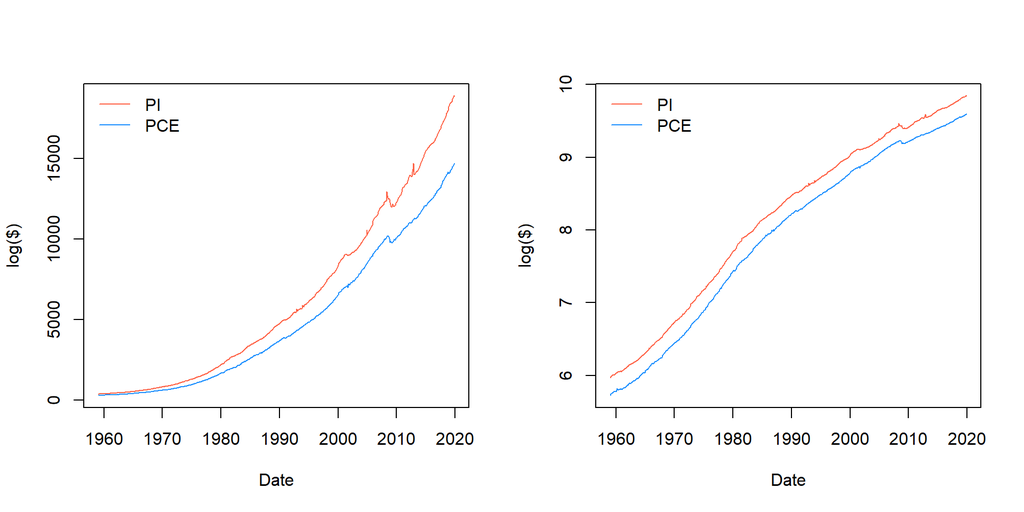

## Cointegration

```r
reg <- lm(log(PCE) ~ log(PI), data = pi)
summary(reg)
```

```
Call:
lm(formula = log(PCE) ~ log(PI), data = pi)

Residuals:
      Min        1Q    Median        3Q       Max
-0.059112 -0.014470 -0.003781  0.016900  0.057097

Coefficients:
              Estimate Std. Error t value Pr(>|t|)
(Intercept) -0.3604532  0.0056156  -64.19   <2e-16 ***
log(PI)      1.0134213  0.0006801 1490.18   <2e-16 ***
---
Signif. codes:  0 '***' 0.001 '**' 0.01 '*' 0.05 '.' 0.1 ' ' 1

Residual standard error: 0.02196 on 730 degrees of freedom
Multiple R-squared:  0.9997,    Adjusted R-squared:  0.9997
F-statistic: 2.221e+06 on 1 and 730 DF,  p-value: < 2.2e-16
```

## Cointegration

```r
plot(pi$DATE,
     reg$residuals,
     xlab = "Time", ylab = "",
     main = expression(paste("Residuals from: log(PCE"[t], ") = ", alpha, " + ", beta, "log(PI"[t], ")")),
     type = "l")
```

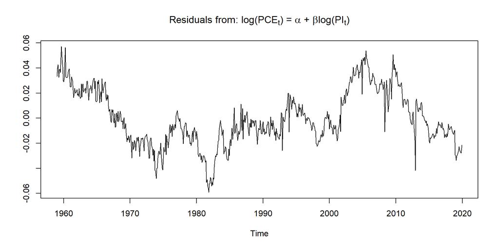

## Cointegration

Since the residuals are *not* $I(0)$, consumption and income are not cointegrated.

```r
tseries::adf.test(reg$residuals)
```

```
    Augmented Dickey-Fuller Test

data:  reg$residuals
Dickey-Fuller = -2.9276, Lag order = 9, p-value = 0.1857
alternative hypothesis: stationary
```

## Cointegration

Error Correction Model: the change of one series is explained in terms of:

- the lag of the difference between the series
- lags of the differences of each series

$$\begin{align}\Delta y_t &= \Sigma_{i = 1}^{p} \alpha_{i} \Delta y_{t-i} \\ &+ \Sigma_{j = 1}^{q} \beta_{j} \Delta x_{t-j} \\ &+ \gamma z_{t-1} + \mu + e_t\end{align}$$

## Cointegration

Suppose income and consumption were in fact cointegrated. How would we estimate the model?

```r
pi_ts <- ts(pi, start = c(1959, 1), frequency = 12)
pi_ts <- ts.intersect(pi_ts,
                      pc = diff(log(pi_ts[,"PCE"])),
                      pi = diff(log(pi_ts[,"PI"])))
colnames(pi_ts) <- c("DATE", "PI", "PCE", "pc", "pi")

pi_ts <- ts.union(pi_ts, reg$residuals[2:length(reg$residuals)])
colnames(pi_ts) <- c("DATE", "PI", "PCE", "pc", "pi", "z")
```

## Cointegration

- ACF
- PACF

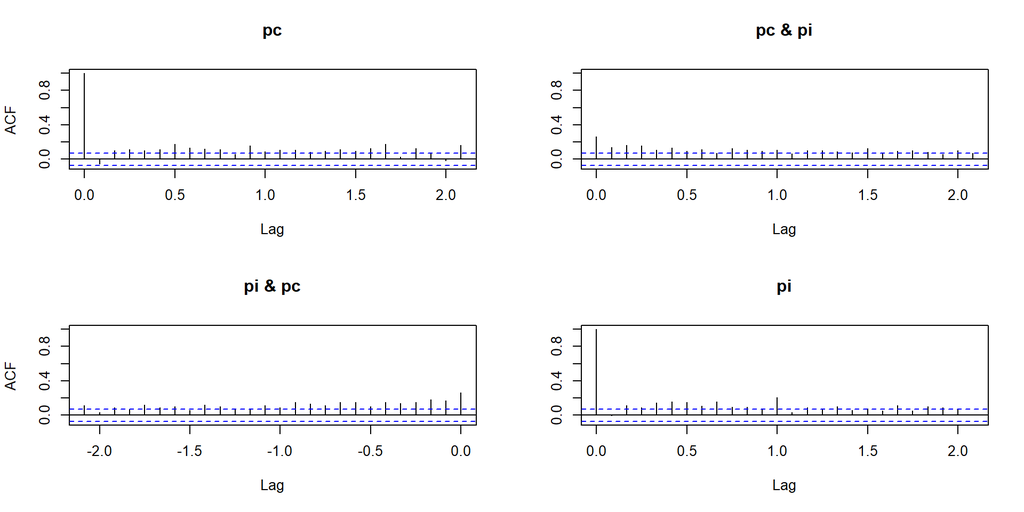

```r
acf(pi_ts[,c("pc", "pi")])
```

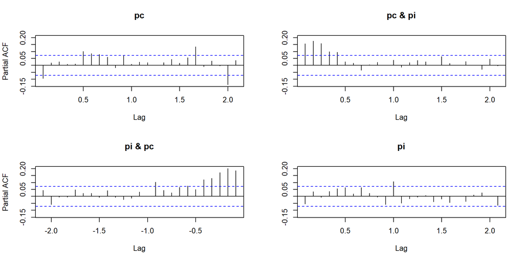

```r
pacf(pi_ts[,c("pc", "pi")])
```

## Cointegration

```r
# pi_ts <- ts.union(pi_ts, reg$residuals[2:length(reg$residuals)])
# colnames(pi_ts) <- c("DATE", "PI", "PCE", "pc", "pi", "z")

rmv.q <- c() # y-vars
rmv.p <- list(pi = c(), z = c(0, 2:12)) # x-vars
rmv <- list(p = rmv.p, q = rmv.q)
main <- ardlDlm(formula = pc ~ pi + z,
              data = as.data.frame(pi_ts),
              p = 12,
              q = 12,
              remove = rmv)
summary(main)
```

```
Time series regression with "ts" data:
Start = 13, End = 731

Call:
dynlm(formula = as.formula(model.text), data = data)

Residuals:
       Min         1Q     Median         3Q        Max
-0.0218796 -0.0024900 -0.0000841  0.0027765  0.0236268

Coefficients:
              Estimate Std. Error t value Pr(>|t|)
(Intercept)  0.0024010  0.0005351   4.487 8.45e-06 ***
pi.t         0.2577396  0.0367299   7.017 5.41e-12 ***
pi.1         0.1427268  0.0388892   3.670 0.000261 ***
pi.2         0.1390537  0.0390799   3.558 0.000399 ***
pi.3         0.1208001  0.0394285   3.064 0.002270 **
pi.4         0.0336543  0.0396888   0.848 0.396757
pi.5         0.0087431  0.0395938   0.221 0.825297
pi.6        -0.0454194  0.0394691  -1.151 0.250229
pi.7        -0.0369035  0.0394333  -0.936 0.349679
pi.8        -0.0806267  0.0393097  -2.051 0.040636 *
pi.9        -0.0231455  0.0392077  -0.590 0.555162
pi.10       -0.0036435  0.0387130  -0.094 0.925045
pi.11       -0.0053696  0.0379922  -0.141 0.887647
pi.12       -0.0068108  0.0370442  -0.184 0.854181
z.1         -0.0356259  0.0102078  -3.490 0.000514 ***
pc.1        -0.2174941  0.0384251  -5.660 2.22e-08 ***
pc.2        -0.0871550  0.0397149  -2.195 0.028530 *
pc.3        -0.0487803  0.0401043  -1.216 0.224271
pc.4        -0.0217107  0.0403061  -0.539 0.590305
pc.5         0.0194078  0.0404392   0.480 0.631432
pc.6         0.1180546  0.0404596   2.918 0.003639 **
pc.7         0.0959361  0.0407643   2.353 0.018880 *
pc.8         0.0794330  0.0409547   1.940 0.052842 .
pc.9         0.0548218  0.0408454   1.342 0.179978
pc.10       -0.0098468  0.0405019  -0.243 0.807985
pc.11        0.0510592  0.0398659   1.281 0.200702
pc.12        0.0079616  0.0382834   0.208 0.835319
---
Signif. codes:  0 '***' 0.001 '**' 0.01 '*' 0.05 '.' 0.1 ' ' 1

Residual standard error: 0.004938 on 692 degrees of freedom
Multiple R-squared:  0.2077,    Adjusted R-squared:  0.1779
F-statistic: 6.976 on 26 and 692 DF,  p-value: < 2.2e-16
```

## Cointegration

What does a negative coefficient mean?

The residual is positive when $\text{consumption} > \alpha + \beta \times\text{income}$. Remember, these two things are $\approx$ when in equilibrium.

In other words, if last period’s consumption is greater than the equilibrium amount, this period’s change in consumption will be less – snapping the relationship back towards equilibrium.

# HW 5: Forecasting AIDS

## AIDS

Forecast the next 2 years of AIDS deaths (1994Q2 - 1996Q1).

```r
# Forecast

tmp3 <- readRDS("../data/aids.RDS")

tmp <- aggregate(list(death = tmp3$deaths,
                      diag = tmp3$diag),
                 list(month = tmp3$month),
                 sum, na.rm = TRUE)
ifelse(tmp$death == 0, NA, tmp$death) -> tmp$death
ifelse(tmp$diag == 0, NA, tmp$diag) -> tmp$diag
tmp <- tmp[year(tmp$month) >= 1987,]

lim1 <- tmp$month <= ymd("1994-04-01") & !is.na(tmp$death)

plot_all <- function(months = 0){

  plot(tmp$month, tmp$diag, type = "n",
       xlab = "Month", ylab = "Quantity")
  lines(tmp$month[lim1], tmp$diag[lim1], type = "l", col = "black", lwd = 3)
  lines(tmp$month[lim1] - months(months), tmp$death[lim1], col = "dodgerblue", lwd = 3)
  abline(v = ymd(c("1993-01-01", "1994-04-15")), lty = c(1, 2))
  legend("topright", bty = "n", col = c("black", "dodgerblue"), lty = 1,
         legend = c("Diagnoses", "Deaths"), lwd = 2)
}

plot_all()
```

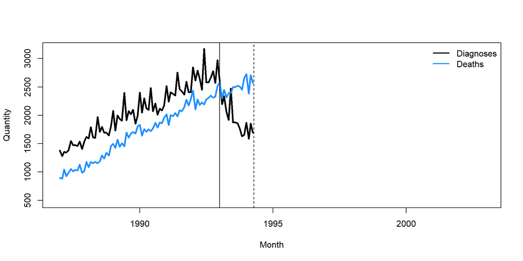

## AIDS

HW: Use diagnoses to improve on this ARIMA model:

```r
# Forecast AIDS deaths from 1994-04-01 through 1996-03-01.

library("lubridate")
library("tseries")
library("forecast")
rm(list = ls())
# setwd(paste0("C:/Users/",Sys.info()["users"],"/Dropbox/teaching/Fall 2022/econ707/data"))
tmp3 <- readRDS("../data/aids.RDS")

tmp <- aggregate(list(death = tmp3$deaths,
                      diag = tmp3$diag),
                 list(month = tmp3$month),
                 sum, na.rm = TRUE)
ifelse(tmp$death == 0, NA, tmp$death) -> tmp$death
ifelse(tmp$diag == 0, NA, tmp$diag) -> tmp$diag
tmp <- tmp[year(tmp$month) >= 1987,]

lim1 <- tmp$month <= ymd("1994-04-01") & !is.na(tmp$death)

plot_all <- function(months = 0){

  plot(tmp$month, tmp$diag, type = "n",
       xlab = "Month", ylab = "Quantity")
  lines(tmp$month[lim1], tmp$diag[lim1], type = "l", col = "black", lwd = 3)
  lines(tmp$month[lim1] - months(months), tmp$death[lim1], col = "dodgerblue", lwd = 3)
  abline(v = ymd(c("1993-01-01", "1994-04-15")), lty = c(1, 2))
  legend("topright", bty = "n", col = c("black", "dodgerblue"), lty = 1,
         legend = c("Diagnoses", "Deaths"), lwd = 2)
}

plot_all()

## ARIMA

aids_ts <- ts(tmp[lim1,2:3], start = c(min(year(tmp$month[lim1]))), frequency = 12)

adf.test(diff(aids_ts[,"death"]))
acf(diff(aids_ts[,"death"]))
pacf(diff(aids_ts[,"death"]))

adf.test(diff(diff(aids_ts[,"death"], lag = 12)))
acf(diff(diff(aids_ts[,"death"], lag = 12)))
pacf(diff(diff(aids_ts[,"death"], lag = 12)))

reg1 <- auto.arima(aids_ts[,"death"])
H <- 24
p1 <- predict(reg1, n.ahead = H)
plot_all()
lines(tmp$month[!lim1][1:H],
      p1$pred, col = "tomato", lwd = 3)
lines(tmp$month[!lim1][1:H],
      tmp$death[!lim1][1:H], col = "mediumseagreen", lwd = 3)
legend("bottomright", bty = "n", col = c("tomato", "mediumseagreen"), lty = 1,
       legend = c("ARIMA", "Actual"), lwd = 2)
```

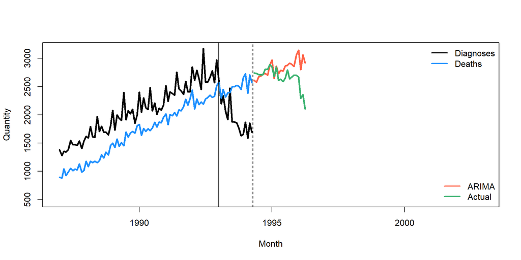

## Next Classes

**11/16**:

- VAR
- Coefficient Dynamics

**11/23**:

- No Class

**11/30**:

- Spatial Autocorrelation
- Project Help

**12/7**:

- Final Presentations

[figure not shown]

ECON 707/807: Econometrics II